# WILD 7970 - SpatialEcology - Lab1

Stephen J. Zenas

2024-01-19

# 1 **Assignment**

Build a fully reproducible map of something relevant to you (e.g., your study site) using R Markdown and GitHub. Upload your R Markdown file to GitHub and provide the link.

## 1.1 Deliverables

- Zoomed-in Map
  - Vector data
  - Raster data
  - additional vector or raster data
- Zoomed-out Map
  - Extent rectangle
- Interpretable legend
- Fully reproducable
- Short summary paragraph
  - background about the study and the study area being mapped
  - information on where the spatial elements in the map were obtained
- Neatness
- BONUS: include a scale bar and North arrow within the final figure

# 2 **Step #1: Import and Modify Data**

## 2.1 Import Data (.csv)

Data in ‘.csv’ format are added to the work space using the ‘read.csv()’ function. The files containes some junk text in the first column name, so in included an additional argument - ‘fileEncoding = “UTF-8-BOM”’ - to ensure that the unnecessary text is removed from the column header

```r
study = read.csv("studyvert.csv",fileEncoding = "UTF-8-BOM")

# preview data
head(study)
```

```
##           X        Y
## 1 -85.73920 32.32642
## 2 -85.73879 32.32630
## 3 -85.73865 32.32580
## 4 -85.73838 32.32550
## 5 -85.73809 32.32539
## 6 -85.73779 32.32541
```

The process was repeated for the second ‘.csv’ file.

```r
cams = read.csv("camlocs.csv",fileEncoding = "UTF-8-BOM")

# preview data
head(cams)
```

```
##          X       Y
## 1 -85.7131 32.2928
## 2 -85.7128 32.2987
## 3 -85.7196 32.2929
## 4 -85.7233 32.2971
## 5 -85.7261 32.2916
## 6 -85.7299 32.2992
```

Both files contain columns corresponding to longitude(X) and latitude(Y).

## 2.2 Import Data (.tif)

Importing raster data is simple with the ‘terra’ package. All that was required was to call the “rast()” function. I verified that the object I created was a spatial object by calling the ‘class()’ function and returning the first value.

```r
elev = rast('dem.tif')

#verify the data type as SpatRaster
class(elev)[1]
```

```
## [1] "SpatRaster"
```

# 3 **Step #2: Convert data to spatial objects**

## 3.1 Vector 1 - Convert non-spatial points to spatial polygon

Currently, the data I have imported from the ‘study’ file lacks spatial information. They are just sets of recorded coordinates. in the following steps, I:

1. verified that the data set was circular (*the first and last points are the same*)
2. extracted the columns containing X and Y data
3. combined them in a polygon geometry
4. Used the ‘SpatialPolygons’ function in thepackage:sp to convert the polygon to a spatial polygon
5. Set the projection
6. Used the ‘st_as_sf’ function to convert the spatial polygon to a ‘sf’ feature.

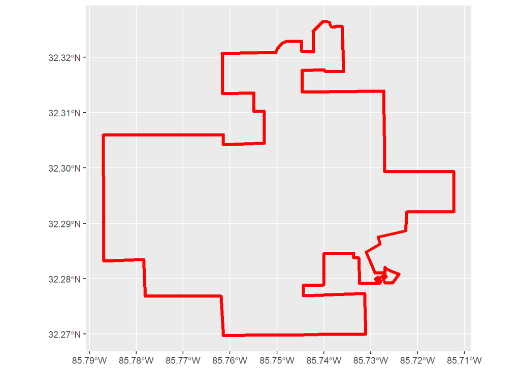

```r
# verify that the first row hasn't already been duplicated
if(study[1,1] != study[nrow(study),1] & study[1,2] != study[nrow(study),2])
{
 study = study %>% add_row(study[1,])
}

# Extract the coordinate values
study.Xcoords = study$X
study.Ycoords = study$Y

# Combine the coordinates into a polygon, then define it as a spatial polygon
pgon = Polygon(cbind(study.Xcoords,study.Ycoords))
pgons = Polygons(list(pgon),1)
spgons = SpatialPolygons(list(pgons))

# set the projection for the spatial polygon
# epsg:4326 corresponds to lat/long data in the WGS1984 datum
proj4string(spgons) = CRS('+init=epsg:4326')

# Define the object as a spatial feature and assign to appropriate object
study.spatial = st_as_sf(spgons)

# Preview the feature
ggplot()+
  geom_sf(data = study.spatial, color = 'red', linewidth = 1.5, fill = NA)
```

## 3.2 Vector 2 - Create Spatial Points from coordinates in .csv file

Converting the camera locations to sf objects was simpler. I was able to call the ‘st_as_sf’ function to produce a ‘sf’ object.

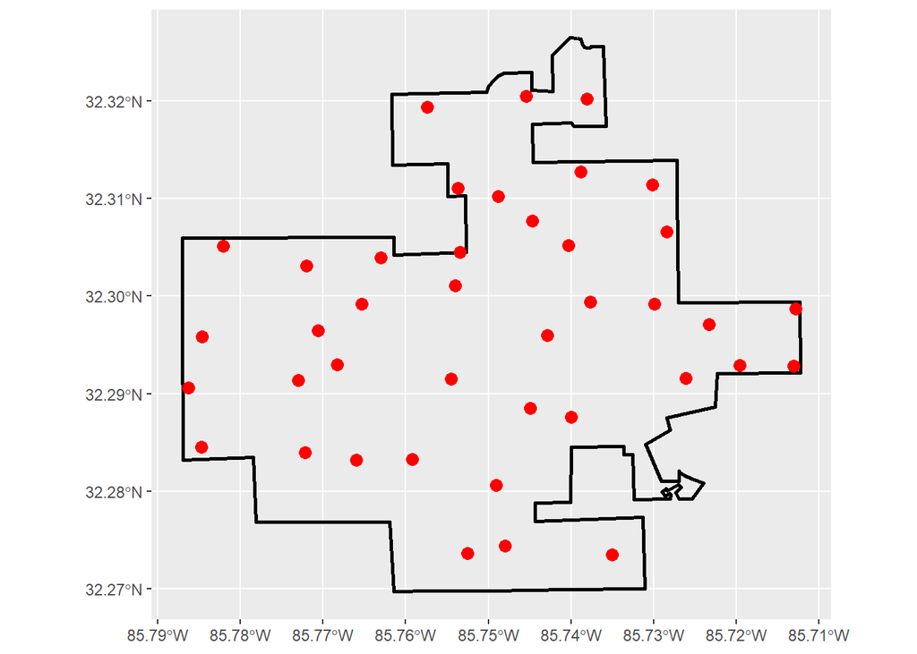

```r
cams.spatial = st_as_sf(cams, coords=c("X","Y"),crs = 'epsg:4326')

# Visualize the feature spatial. Red items indicate new additions to the map.

ggplot()+
  geom_sf(data = study.spatial, fill = NA, color = 'black', linewidth = 1)+
  geom_sf(data = cams.spatial, color = 'red', size = 3)
```

## 3.3 Create Extent Box from study site boundary file

The extent box is based on the study site boundary ‘sf’ object. I began by extracting the bounding box from the study site ‘sf’ object, then added ‘0.001’ degrees to each of the X and Y min/max values. Lastly, I converted the coordinates to a ‘sf’ object.

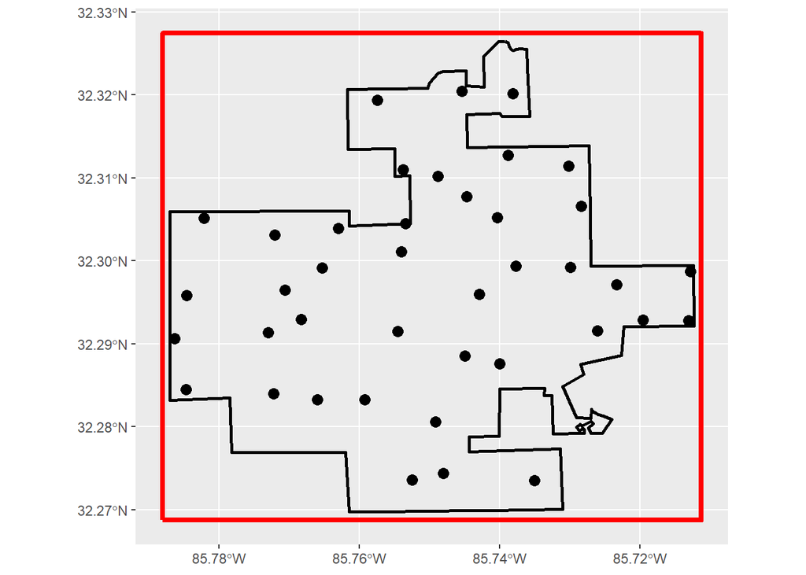

```r
# Define the 'extent' box
extent = st_bbox(study.spatial)
new.extent = extent + c(-.001,-.001,.001,.001)
extent.spatial = st_as_sfc(new.extent)

# View data
ggplot()+
  geom_sf(data = study.spatial, fill = NA, color = 'black', linewidth = 1)+
  geom_sf(data = cams.spatial, color = 'black', size = 3)+
  geom_sf(data = extent.spatial, fill = NA, color = 'red', linewidth = 1.5)
```

## 3.4 Display raster data

The raster data was converted to a ‘spatRaster’ when it was imported, so no additional steps were needed.

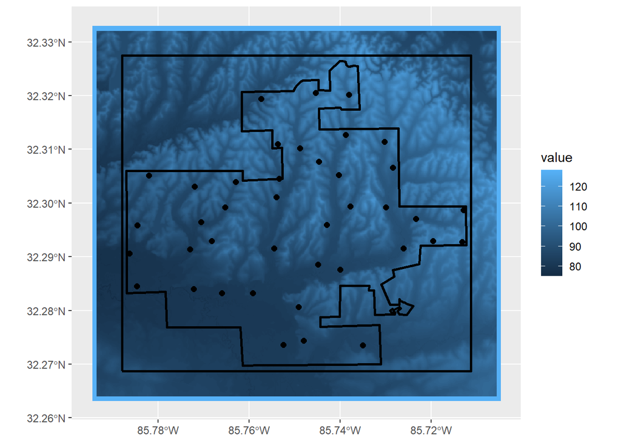

```r
# Raster data is already spatial when imported with 'terra

# visualize the raster spatially
ggplot()+
  geom_spatraster(data = elev)+
  geom_sf(data = study.spatial, fill = NA, color = 'black', linewidth = 1)+
  geom_sf(data = extent.spatial, fill = NA, color = 'black', linewidth = 1)+
  geom_sf(data = cams.spatial, color = 'black', size = 2)
```

## 3.5 Crop Raster to extent window

The raster was a little too large for my map, so I cropped the raster to the study extent window I created in the last step.

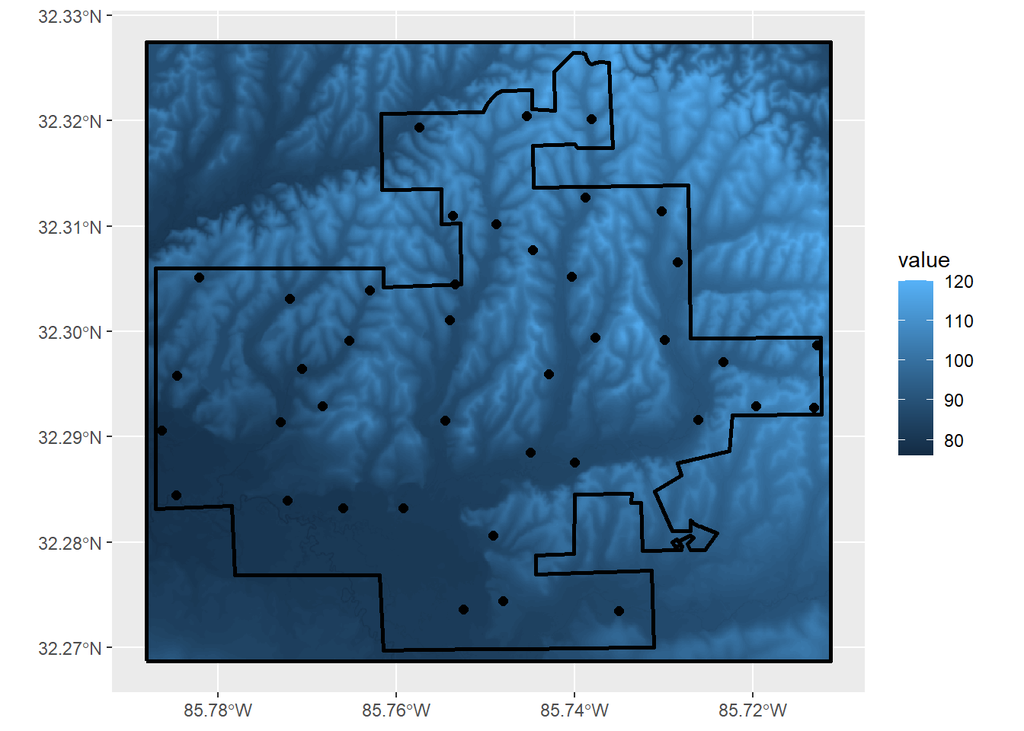

```r
elevcrop = crop(elev, extent.spatial)

# visualize crop
ggplot()+
  geom_spatraster(data = elevcrop)+
  geom_sf(data = study.spatial, fill = NA, color = 'black', linewidth = 1)+
  geom_sf(data = extent.spatial, fill = NA, color = 'black', linewidth = 1)+
  geom_sf(data = cams.spatial, color = 'black', size = 2)
```

## 3.6 Import Macon county, AL shapefile

For my zoomed out map, I chose to use the Macon County,AL extent. The .shp for Macon county was retrieved from the ‘geodata’ package. I filtered all the the counties by the FIPS code (01087). The first two digits of the FIPS code (01###) correspond to the state FIPS code for Alabama. The last three digits (##087) are the unique identifier for Macon County.

The resulting object is not in the appropriate datum, so I projected the Macon County shapefile to the same datum as my study boundary ‘sf’ object.

```r
# Specified results = 'hide to eliminate unnecessary messaging from geodata  function
macon.NAD = counties() %>% filter(GEOID == '01087')
macon = st_transform(macon.NAD,st_crs(study.spatial))
```

Verification of the projection:

```r
print(paste("Before Projection: ",crs(macon.NAD, proj = T)))
```

```
## [1] "Before Projection:  +proj=longlat +datum=NAD83 +no_defs"
```

```r
print(paste("After Projection: ",crs(macon, proj = T)))
```

```
## [1] "After Projection:  +proj=longlat +datum=WGS84 +no_defs"
```

## 3.7 Visualize Macon County .shp

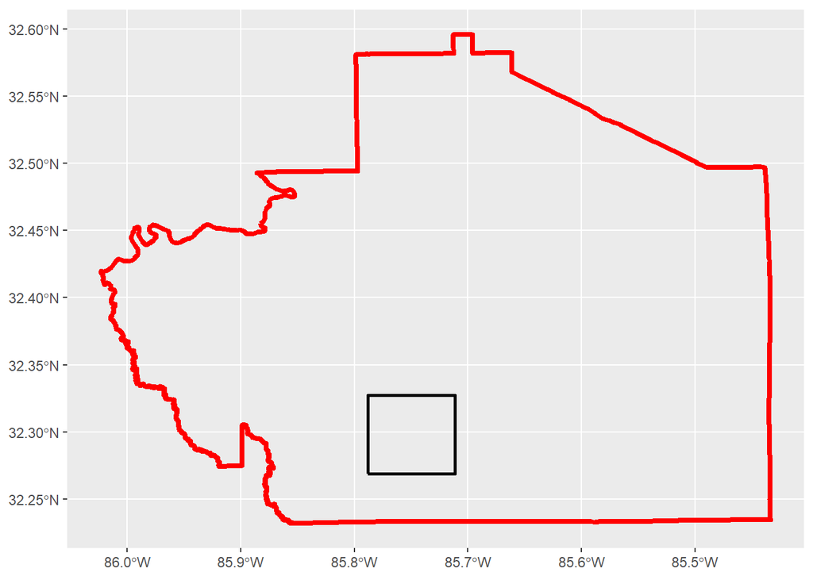

```r
ggplot()+
  geom_sf(data = macon, fill = NA, color = 'red', linewidth = 1.5)+
  geom_sf(data = extent.spatial, fill = NA, color = 'black', linewidth = 1)
```

# 4 **Step #3: Compile map elements**

## 4.1 Create zoomed out map

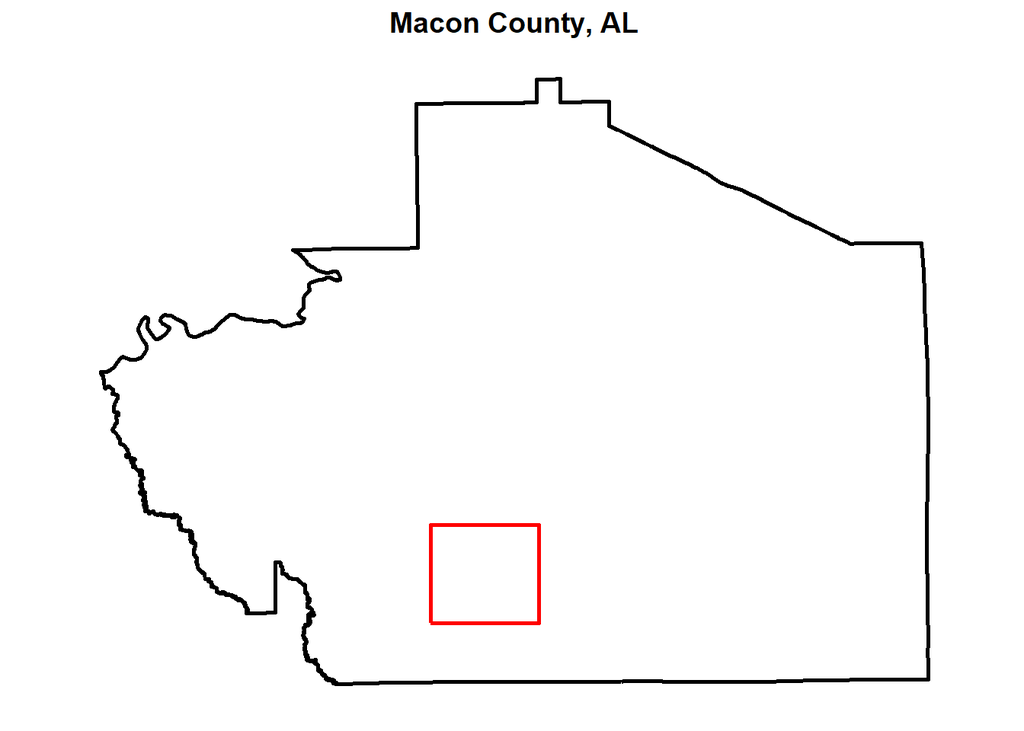

```r
zo = ggplot()+
  # add Macon County polygon
  geom_sf(data = macon, color = 'black', fill = NA, linewidth = 1)+
  # add study extent polygon
  geom_sf(data = extent.spatial, color = 'red', fill = NA, linewidth = 1)+
  # add title
  ggtitle('Macon County, AL')+
  # set theme parameters
  theme_bw()+
  theme(
    plot.title = element_text(hjust = 0.5,size = 14,face = 'bold'),
    panel.grid = element_blank(),
    axis.text = element_blank(),
    axis.ticks = element_blank(),
    panel.border = element_blank())
zo
```

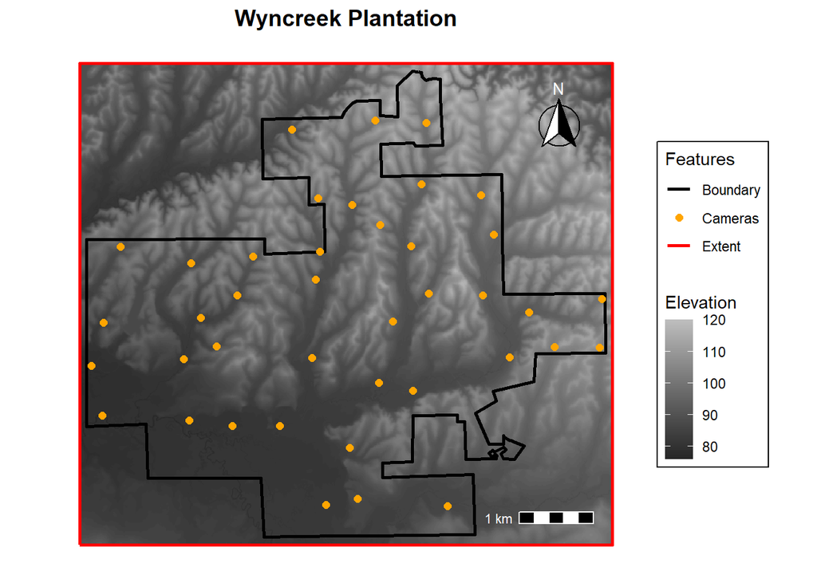

```r
zi = ggplot()+
  # add title
  ggtitle("Wyncreek Plantation")+
  # add raster feature
  geom_spatraster(data = elevcrop)+
  # set the color scale, and lable the variable as elevation
  scale_fill_gradient(low = 'grey15',high = 'grey', na.value = NA, labs(fill = 'Elevation'))

zi = zi+
  # aes(color = "Extent") allows me to specify colors manually for each element
  # show.legend = 'line' allows me to specify the geometry type in the legend
  # add the extent boundary
  geom_sf(data = extent.spatial, fill = NA, linewidth = 1,aes(color = 'Extent'),show.legend = 'line')+

  # add the study area boundary
  geom_sf(data = study.spatial, fill = NA, linewidth = 1,aes(color = 'Boundary'),show.legend = 'line')+

  # add the camera locations
  geom_sf(data = cams.spatial, size = 2, aes(color = "Cameras"),show.legend = 'point')+

  # change the color and geometry type
  scale_color_manual(values = c("Extent" = 'red',"Boundary" = 'black', "Cameras" = 'orange'),
                     guide = guide_legend(override.aes = list(
                       linetype = c('solid','blank','solid'),
                       shape = c(NA,16,NA))))+

  # modify the legend title
  labs(color='Features')+

  # theme parameters
  theme_bw()+
  theme(panel.grid=element_blank(), #Removes the gridlines
        axis.text=element_blank(), #Removes the axis text
        axis.ticks=element_blank(), #Removes the axis tick marks
        plot.title = element_text(hjust = 0.5,size = 14,face = 'bold'),
        panel.border=element_blank())+ #Removes the frame around the graph
  theme(legend.box.background = element_rect(color = 'black'),
        legend.background = element_blank(),
        legend.margin = margin(t = 5, r = 5, b = 5, l = 5, unit='pt'))+

  # Adding North Arrow and Scale bar
  annotation_scale(location = 'br',pad_x = unit(1,'cm'),pad_y = unit(1,'cm'),aes(text_col = 'white',line_col = 'white'))+
  annotation_north_arrow(location = 'tr', which_north = 'true',pad_x = unit(1,'cm'),pad_y = unit(1,'cm'), style = north_arrow_fancy_orienteering(text_col = 'white'))

zi
```

# 5 **Step #4: Produce final map**

The final map was compiled with ‘cowplot’. I created a left panel which containes the zoomed out view and the legend. Additionally, I created a right panel which contains the zoomed in map element.

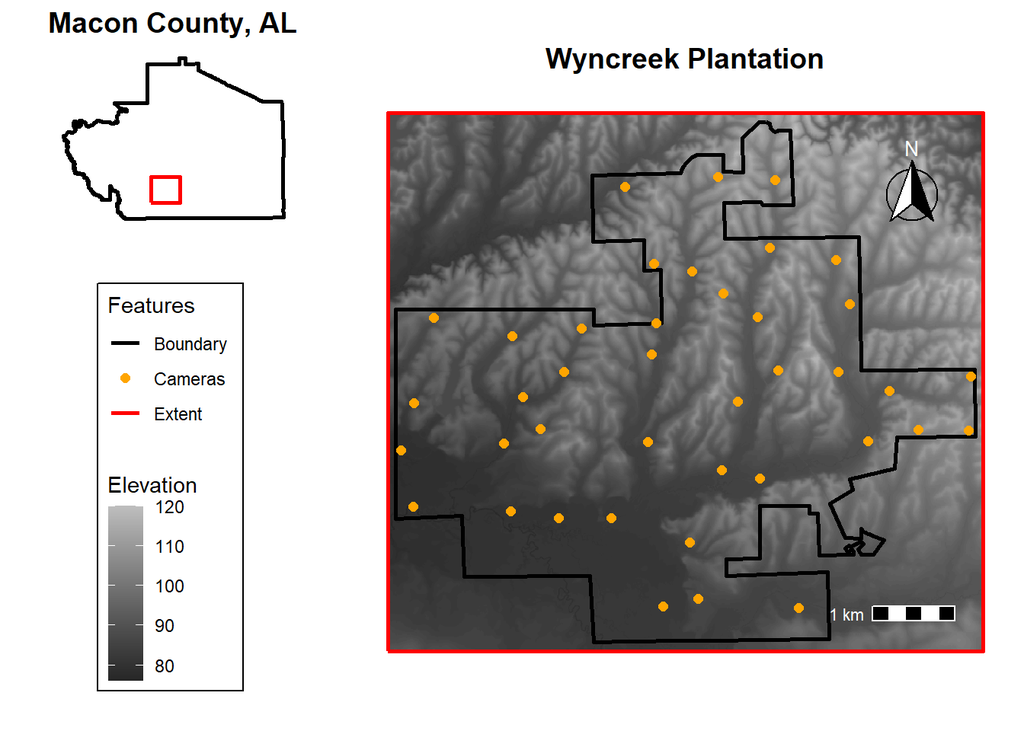

```r
# Extract the Legend
ledge = get_legend(zi)

# Create duplicate zoomed in map, excluding the legend
zi_no_legend = zi + theme(legend.position = 'none')

# Specify the features that will go in the left panel
left.Panel = plot_grid(zo,ledge,ncol = 1,rel_heights = c(1,2))

# Specify the features that will go in the right panel
right.Panel = plot_grid(zi_no_legend)

# Combine panels to create file output
full.Map = plot_grid(left.Panel,right.Panel, rel_widths = c(1,2),align = 'hv')

# Visualize final map product
full.Map
```

# 6 **Step #5: Summary of Map and Data Files**

For the purpose of this assignment, I elected to export the polygon vertices from Arc and recreate the study site boundary in R.

Together, these elements could be used to assess the effect of elevation on detection, abundance, and density of wild pigs. Generally, it is believed that wild pigs have a greater utilization of low lying, wet areas.